# Linear Regression for Prediction

The goal of this notebook is to walk you through the mechanics of exploring complex datasets and designing a predictive model using linear regression.

The example we will use is [Lending Club](https://www.lendingclub.com) , a peer-to-peer lender. The goal is to come up with an algorithm that recommends the interest rate to charge to new loans. The lending club has made historical data publicly available and we will use it for this exercise.

## 0) Getting started with VSCode and Jupyter notebooks

**In the following, we assume that you have downloaded both VSCode and Uv using the instructions available at this [Tech Setup Link](https://www.notion.so/Data-Science-for-Business-Tech-Setup-Requirements-259c11fb2e308042b7e1d4b7924e2508).**

VSCode is quite intuitive to use, but it does require some time to get used to. In particular, make sure that you are familiare with the following!

1. First of all, make sure that you have opened the folder AM04 with VSCode.
2. Sync the project! Open the VSCode terminal, go on View > Terminal. In the terminal type uv sync.
3. This will create a virtual environment called AM04 which you will be using throughout the whole course. Here we will keep all the relevant data science packages.
4. Set the correct environment to run the notebook. In the top right corner of your screen you should already see the correct virtual environment called am04, see picture below. In this case, you are ready to run the code. Instead, if you see a "Select Kernel" command, then click on it, select Python Environments and, finally, click on am04 (it should also be recommended at the top!) **If VSCode prompts you to install suggested extensions Python+Jupyter, please click yes!**

[figure not shown]

## 1) Load the data

```python
# Localized imports for this section
import pandas as pd

df = pd.read_csv("LendingClub_Data.csv", skiprows=1, low_memory=False)
df.head()
```

|  | int_rate | loan_amnt | term (months) | installment | dti | delinq_2yrs | annual_inc | grade | emp_title | emp_length | ... | Unnamed: 70 | Unnamed: 71 | Unnamed: 72 | Unnamed: 73 | Unnamed: 74 | Unnamed: 75 | Unnamed: 76 | Unnamed: 77 | Unnamed: 78 | Unnamed: 79 |
| --- | --- | --- | --- | --- | --- | --- | --- | --- | --- | --- | --- | --- | --- | --- | --- | --- | --- | --- | --- | --- | --- |
| 0 | 0.05 | 8000 | 36.0 | 241.28 | 2.11 | 0.0 | 50000.0 | A | NaN | 5 years | ... | NaN | NaN | NaN | NaN | NaN | NaN | NaN | NaN | NaN | NaN |
| 1 | 0.05 | 6000 | 36.0 | 180.96 | 5.73 | 0.0 | 52800.0 | A | coral graphics | < 1 year | ... | NaN | NaN | NaN | NaN | NaN | NaN | NaN | NaN | NaN | NaN |
| 2 | 0.05 | 6500 | 36.0 | 196.04 | 17.68 | 0.0 | 35352.0 | A | NaN | NaN | ... | NaN | NaN | NaN | NaN | NaN | NaN | NaN | NaN | NaN | NaN |
| 3 | 0.05 | 8000 | 36.0 | 241.28 | 22.71 | 0.0 | 79200.0 | A | Honeywell | NaN | ... | NaN | NaN | NaN | NaN | NaN | NaN | NaN | NaN | NaN | NaN |
| 4 | 0.05 | 5500 | 36.0 | 165.88 | 5.75 | 0.0 | 240000.0 | A | O T Plus, Inc | 10+ years | ... | NaN | NaN | NaN | NaN | NaN | NaN | NaN | NaN | NaN | NaN |

5 rows × 80 columns

```python
df.shape
```

```
(42538, 80)
```

```python
df.describe()
```

|  | int_rate | term (months) | installment | dti | delinq_2yrs | annual_inc | Unnamed: 19 | Unnamed: 20 | Unnamed: 21 | Unnamed: 22 | ... | Unnamed: 70 | Unnamed: 71 | Unnamed: 72 | Unnamed: 73 | Unnamed: 74 | Unnamed: 75 | Unnamed: 76 | Unnamed: 77 | Unnamed: 78 | Unnamed: 79 |
| --- | --- | --- | --- | --- | --- | --- | --- | --- | --- | --- | --- | --- | --- | --- | --- | --- | --- | --- | --- | --- | --- |
| count | 37869.000000 | 37869.000000 | 37869.000000 | 37869.000000 | 37869.000000 | 3.786900e+04 | 0.0 | 0.0 | 0.0 | 0.0 | ... | 0.0 | 0.0 | 0.0 | 0.0 | 0.0 | 0.0 | 0.0 | 0.0 | 2660.0 | 2720.000000 |
| mean | 0.120264 | 42.461222 | 332.581354 | 13.284162 | 0.145554 | 6.914786e+04 | NaN | NaN | NaN | NaN | ... | NaN | NaN | NaN | NaN | NaN | NaN | NaN | NaN | 0.0 | 2.235294 |
| std | 0.037264 | 10.645418 | 214.289826 | 6.686636 | 0.491173 | 6.166703e+04 | NaN | NaN | NaN | NaN | ... | NaN | NaN | NaN | NaN | NaN | NaN | NaN | NaN | 0.0 | 116.061941 |
| min | 0.050000 | 36.000000 | 15.680000 | 0.000000 | 0.000000 | 4.000000e+03 | NaN | NaN | NaN | NaN | ... | NaN | NaN | NaN | NaN | NaN | NaN | NaN | NaN | 0.0 | 0.000000 |
| 25% | 0.090000 | 36.000000 | 168.590000 | 8.140000 | 0.000000 | 4.080000e+04 | NaN | NaN | NaN | NaN | ... | NaN | NaN | NaN | NaN | NaN | NaN | NaN | NaN | 0.0 | 0.000000 |
| 50% | 0.120000 | 36.000000 | 288.330000 | 13.360000 | 0.000000 | 5.953400e+04 | NaN | NaN | NaN | NaN | ... | NaN | NaN | NaN | NaN | NaN | NaN | NaN | NaN | 0.0 | 0.000000 |
| 75% | 0.150000 | 60.000000 | 449.050000 | 18.580000 | 0.000000 | 8.280000e+04 | NaN | NaN | NaN | NaN | ... | NaN | NaN | NaN | NaN | NaN | NaN | NaN | NaN | 0.0 | 0.000000 |
| max | 0.250000 | 60.000000 | 1305.190000 | 29.990000 | 11.000000 | 6.000000e+06 | NaN | NaN | NaN | NaN | ... | NaN | NaN | NaN | NaN | NaN | NaN | NaN | NaN | 0.0 | 6053.000000 |

8 rows × 67 columns

```python
df.dtypes
```

```
int_rate         float64
loan_amnt         object
term (months)    float64
installment      float64
dti              float64
                  ...
Unnamed: 75      float64
Unnamed: 76      float64
Unnamed: 77      float64
Unnamed: 78      float64
Unnamed: 79      float64
Length: 80, dtype: object
```

## 2) Quick cleaning of the data

```python
df_clean = df.iloc[:,:19]
df_clean = df_clean[ df_clean['int_rate'].notna() ]
df_clean['issue_d'] = pd.to_datetime(df_clean['issue_d'], format='%m/%d/%Y', errors='coerce')
df_clean['term'] = df_clean['term (months)'].astype('category')
df_clean['delinq_2yrs'] = df_clean['delinq_2yrs'].astype('category')
df_clean['loan_amnt'] = pd.to_numeric(df_clean['loan_amnt'], errors='coerce')
df_clean = df_clean.drop(columns=['emp_title', 'installment', 'term (months)'])
df_clean.head()
```

|  | int_rate | loan_amnt | dti | delinq_2yrs | annual_inc | grade | emp_length | home_ownership | verification_status | issue_d | zip_code | addr_state | loan_status | desc | purpose | title | term |
| --- | --- | --- | --- | --- | --- | --- | --- | --- | --- | --- | --- | --- | --- | --- | --- | --- | --- |
| 0 | 0.05 | 8000 | 2.11 | 0.0 | 50000.0 | A | 5 years | MORTGAGE | Verified | 2011-09-01 | 977xx | OR | Fully Paid | Borrower added on 09/08/11 > Consolidating d... | debt_consolidation | Credit Card Payoff $8K | 36.0 |
| 1 | 0.05 | 6000 | 5.73 | 0.0 | 52800.0 | A | < 1 year | MORTGAGE | Source Verified | 2011-09-01 | 228xx | VA | Charged Off | Borrower added on 09/08/11 > excellent credi... | vacation | bad choice | 36.0 |
| 2 | 0.05 | 6500 | 17.68 | 0.0 | 35352.0 | A | NaN | MORTGAGE | Not Verified | 2011-09-01 | 864xx | AZ | Fully Paid | Borrower added on 09/09/11 > I plan to use t... | credit_card | Credit Card Loan | 36.0 |
| 3 | 0.05 | 8000 | 22.71 | 0.0 | 79200.0 | A | NaN | MORTGAGE | Verified | 2011-09-01 | 322xx | FL | Fully Paid | Borrower added on 09/08/11 > Home improvemen... | home_improvement | Home Improvement | 36.0 |
| 4 | 0.05 | 5500 | 5.75 | 0.0 | 240000.0 | A | 10+ years | MORTGAGE | Source Verified | 2011-09-01 | 278xx | NC | Fully Paid | NaN | car | Car Loan | 36.0 |

```python
df_clean.dtypes
```

```
int_rate                      float64
loan_amnt                       int64
dti                           float64
delinq_2yrs                  category
annual_inc                    float64
grade                          object
emp_length                     object
home_ownership                 object
verification_status            object
issue_d                datetime64[ns]
zip_code                       object
addr_state                     object
loan_status                    object
desc                           object
purpose                        object
title                          object
term                         category
dtype: object
```

## 3) Exploratory Data Analysis

There are two main plotting libraries in Python. Matplotlib is the standard one. Here we will also use seaborn, which allows for creating more complex and beautiful plots.

```python
import seaborn as sns
from matplotlib import pyplot as plt
```

### Histograms

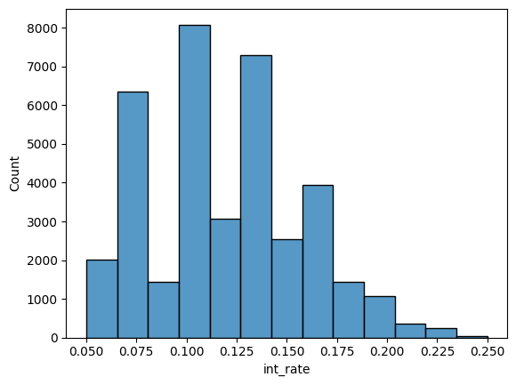

```python
sns.histplot(data=df_clean,
             x='int_rate',
             binwidth=0.015)
```

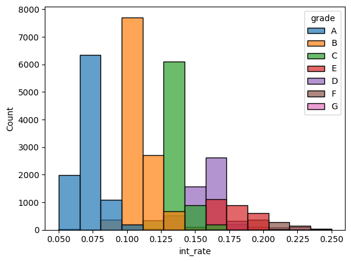

```python
sns.histplot(data=df_clean,
             x='int_rate',
             hue='grade',
             multiple='layer',
             alpha=0.7,
             binwidth=0.015)
```

### Density Plot

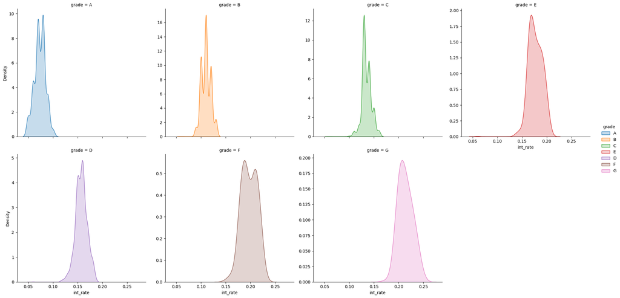

```python
sns.displot(
    data=df_clean,
    x="int_rate",
    hue="grade",         # give each grade its own color (like fill)
    kind="kde",
    bw_adjust= 2,
    fill=True,
    facet_kws={"sharey": False},  # so y-axis scales independently per facet
    col="grade",         # facet by grade
    col_wrap=4          # wrap into rows of 4 plots
)
```

### Box plots

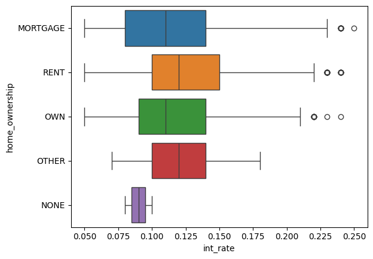

```python
sns.boxplot(
    data=df_clean,
    y="home_ownership",
    x="int_rate",
    hue="home_ownership",
    dodge=False,
)
```

### Scatter plot and regression lines

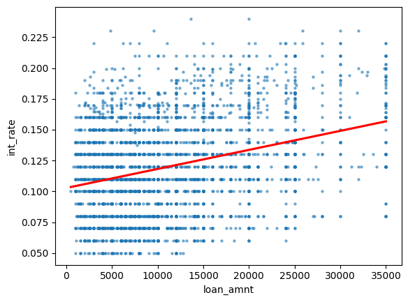

```python
df_sample = df_clean.iloc[::10, :] # subsample just for visualisation purposes
sns.regplot(
    data=df_sample,
    x="loan_amnt",
    y="int_rate",
    scatter_kws={"s": 5, "alpha": 0.5},  # size ~0.1 in ggplot
    line_kws={"color": "red"},           # regression line
    ci=None                              # se=0 (no confidence band)
)
```

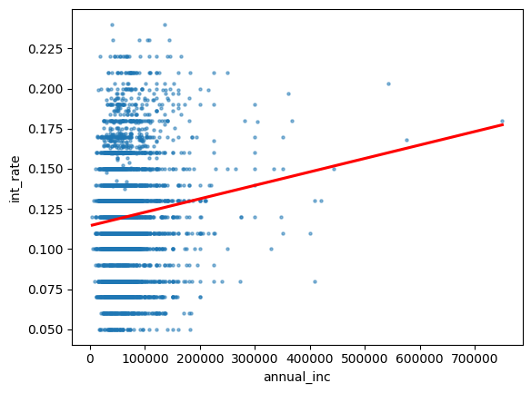

```python
sns.regplot(
    data=df_sample,
    x="annual_inc",
    y="int_rate",
    scatter_kws={"s": 5, "alpha": 0.5},  # size ~0.1 in ggplot
    line_kws={"color": "red"},           # regression line
    ci=None                              # se=0 (no confidence band)
)
```

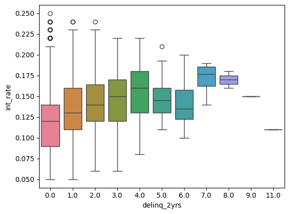

```python
sns.boxplot(
    data=df_clean,
    x="delinq_2yrs",
    y="int_rate",
    hue="delinq_2yrs",     # colour by delinq_2yrs
    dodge=False,
)
plt.legend([], [], frameon=False)
```

### Do delinquencies in the last two years impact interest rates?

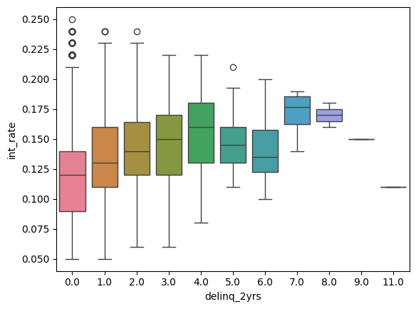

```python
sns.boxplot(
    data=df_clean,
    x="delinq_2yrs",
    y="int_rate",
    hue="delinq_2yrs"    # colour by delinq_2yrs
)
plt.legend([], [], frameon=False)
```

### Correlation Table

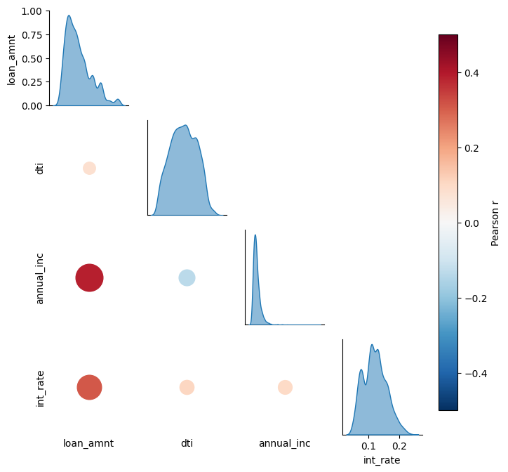

```python
import seaborn as sns, matplotlib.pyplot as plt, numpy as np
from matplotlib.colors import Normalize

vars_order = ['loan_amnt','dti','annual_inc','int_rate']
df_plot = df_clean.iloc[::10, :].copy()

# bubble plot for correlations
def corr_dot(x, y, **kws):
    ax = plt.gca()
    x, y = np.asarray(x, float), np.asarray(y, float)
    m = np.isfinite(x) & np.isfinite(y)
    r = 0.0 if m.sum() < 2 else np.corrcoef(x[m], y[m])[0, 1]
    # scatter bubble in middle of cell
    ax.scatter(0.5, 0.5, s=2000*abs(r), c=[[r]],
               cmap=kws["cmap"], norm=kws["norm"],
               transform=ax.transAxes)
    # clean ticks & spines but KEEP axis for labels
    ax.set_xticks([]); ax.set_yticks([])
    for spine in ax.spines.values(): spine.set_visible(False)

# hide upper triangle completely
def hide_axis(*args, **kwargs):
    plt.gca().set_visible(False)

g = sns.PairGrid(df_plot, vars=vars_order, diag_sharey=False, height=1.7)
# diagonal: filled KDE
g.map_diag(
    sns.kdeplot,
    fill=True, alpha=0.5
)
norm = Normalize(-0.5, 0.5)
g.map_lower(corr_dot, norm=norm, cmap="RdBu_r")
g.map_upper(hide_axis)

# labels for lower axes
for ax, lab in zip(g.axes[-1, :], vars_order): ax.set_xlabel(lab)
for ax, lab in zip(g.axes[:, 0], vars_order):  ax.set_ylabel(lab)

# colorbar
sm = plt.cm.ScalarMappable(norm=norm, cmap="RdBu_r"); sm.set_array([])
g.fig.colorbar(sm, ax=g.axes, fraction=0.046, pad=0.04, label="Pearson r")

plt.show()
```

## 4) Linear Regression

```python
import numpy as np
import statsmodels.formula.api as smf
```

### The simplest linear regression: fitting the mean to the data

```python
model0 = smf.ols('int_rate ~ 1', data=df_clean).fit()
print(model0.summary())
```

```
                            OLS Regression Results
==============================================================================
Dep. Variable:               int_rate   R-squared:                      -0.000
Model:                            OLS   Adj. R-squared:                 -0.000
Method:                 Least Squares   F-statistic:                       nan
Date:                Wed, 30 Sep 2026   Prob (F-statistic):                nan
Time:                        19:49:57   Log-Likelihood:                 70845.
No. Observations:               37869   AIC:                        -1.417e+05
Df Residuals:                   37868   BIC:                        -1.417e+05
Df Model:                           0
Covariance Type:            nonrobust
==============================================================================
                 coef    std err          t      P>|t|      [0.025      0.975]
------------------------------------------------------------------------------
Intercept      0.1203      0.000    628.034      0.000       0.120       0.121
==============================================================================
Omnibus:                      972.461   Durbin-Watson:                   0.000
Prob(Omnibus):                  0.000   Jarque-Bera (JB):              816.859
Skew:                           0.292   Prob(JB):                    4.18e-178
Kurtosis:                       2.580   Cond. No.                         1.00
==============================================================================

Notes:
[1] Standard Errors assume that the covariance matrix of the errors is correctly specified.
```

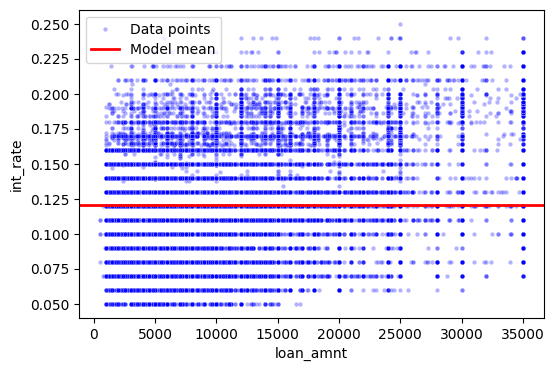

```python
plt.figure(figsize=(6,4))
# Scatter plot
sns.scatterplot(x=df_clean["loan_amnt"], y=df_clean['int_rate'], alpha=0.3, s=10, color="blue", label="Data points")

# Model mean as horizontal line
plt.axhline(model0.params.iloc[0], color="red", linewidth=2, label="Model mean")
plt.legend()
```

### Univariate linear regression: using loan_amnt as a predictor

```python
model1 = smf.ols('int_rate ~ loan_amnt', data=df_clean).fit()
print(model1.summary())
```

```
                            OLS Regression Results
==============================================================================
Dep. Variable:               int_rate   R-squared:                       0.097
Model:                            OLS   Adj. R-squared:                  0.097
Method:                 Least Squares   F-statistic:                     4067.
Date:                Wed, 30 Sep 2026   Prob (F-statistic):               0.00
Time:                        19:50:05   Log-Likelihood:                 72776.
No. Observations:               37869   AIC:                        -1.455e+05
Df Residuals:                   37867   BIC:                        -1.455e+05
Df Model:                           1
Covariance Type:            nonrobust
==============================================================================
                 coef    std err          t      P>|t|      [0.025      0.975]
------------------------------------------------------------------------------
Intercept      0.1028      0.000    312.155      0.000       0.102       0.103
loan_amnt   1.555e-06   2.44e-08     63.770      0.000    1.51e-06     1.6e-06
==============================================================================
Omnibus:                     1206.933   Durbin-Watson:                   0.180
Prob(Omnibus):                  0.000   Jarque-Bera (JB):              751.554
Skew:                           0.211   Prob(JB):                    6.34e-164
Kurtosis:                       2.453   Cond. No.                     2.44e+04
==============================================================================

Notes:
[1] Standard Errors assume that the covariance matrix of the errors is correctly specified.
[2] The condition number is large, 2.44e+04. This might indicate that there are
strong multicollinearity or other numerical problems.
```

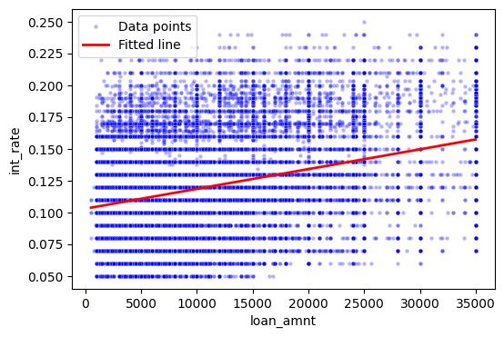

```python
plt.figure(figsize=(6,4))
# Scatter plot
x=df_clean["loan_amnt"]
y=df_clean['int_rate']

sns.scatterplot(x=x, y=y, alpha=0.3, s=10, color="blue", label="Data points")

# x range for predictions
x_vals = np.linspace(x.min(), x.max(), 200)

# build DataFrame with the predictor name matching the formula
X_pred = pd.DataFrame({'loan_amnt': x_vals})

# use model.predict on this DataFrame
y_pred = model1.predict(X_pred)

# plot
plt.plot(x_vals, y_pred, color="red", linewidth=2, label="Fitted line")
plt.legend()
```

```python
from statsmodels.stats.anova import anova_lm
anova_res = anova_lm(model0, model1)  # order: smaller, then larger model
print(anova_res)
```

```
   df_resid        ssr  df_diff   ss_diff            F  Pr(>F)
0   37868.0  52.584888      0.0       NaN          NaN     NaN
1   37867.0  47.485333      1.0  5.099555  4066.621006     0.0
```